# STA 141A winter 2025 Final Report

Han Zhou

2025-02-10

# Introduction

In this project, I aim to understand how activity is associated with decision-making processes. I used a dataset of 18 experimental sessions from 4 mice to analyze how brain activity in the visual cortex affects their ability to make correct choices in visual tasks. During the experiment, mice were presented with visual stimuli of different contrasts, which were displayed on two screens. Mice need to rotate a wheel to determine which side has higher contrast, and ultimately their choice determines whether they succeed or fail. The goal of the project is to integrate and analyze this data to explore patterns of brain activity, especially changes in neural activity over different time periods, and how they affect mouse choices, in order to understand their connection with decision-making processes.

During the analysis process, I conducted data cleaning and integration, preprocessed data from different experimental sessions, and ensured that all necessary variables (such as contrast differences, spike rate, feedback types, etc.) were correctly integrated. Then, I used the XGBoost model for prediction, evaluating which factors were most important for the predicted results by combining time and experimental feedback types. In order t analyze the performance of the model, I also used various evaluation metrics such as accuracy, confusion matrix, etc. to visualize the model’s performance in predicting success and failure.

# 2)-Exploratory analysis

### 2.1) Basic information of 18 session

```r
set.seed(456)
```

```
##   session_id mouse_name       date neuron_count trial_count mean_contrast_left
## 1          1       Cori 2016-12-14          734         114          0.2960526
## 2          2       Cori 2016-12-17         1070         251          0.3177291
## 3          3       Cori 2016-12-18          619         228          0.2357456
## 4          4  Forssmann 2017-11-01         1769         249          0.3343373
## 5          5  Forssmann 2017-11-02         1077         254          0.3385827
## 6          6  Forssmann 2017-11-04         1169         290          0.3534483
##   mean_contrast_right success_count failure_count success_rate
## 1           0.4298246            69            45    0.6052632
## 2           0.3515936           159            92    0.6334661
## 3           0.3684211           151            77    0.6622807
## 4           0.3222892           166            83    0.6666667
## 5           0.3562992           168            86    0.6614173
## 6           0.3250000           215            75    0.7413793
```

Firstly, I analyzed the specific information of 18 sessions and created a table, including the mouse names, experiment dates, number of experiments, number of neurons, average contrast between left and right , as well as the number and success rate of successful and failed experiments for each session. The number of neurons in each session ranges from 474 to 1769. Forssmann’s session 4 has the highest number of neurons (1769), while Lederberg’s session 16 has the lowest number (474). There is also a difference in the number of experiments, with session 10(Hench) having the highest number of experiments (447), while Cori’s session 1 had the lowest (114). The majority of sessions have a success rate between 0.6 and 0.8, with Lederberg’s session 17 (83.06%) being the highest and Cori’s session 1 (60.52%) being the lowest. The mean contrast_reft ranges from 0.23 to 0.44, and the right contrast ranges from 0.26 to 0.43.

### 2.2) relationship between the difference in contrast and feedback type

```
##   session_id trial_id mouse_name contrast_diff feedback_type
## 1          1        1       Cori           0.5             1
## 2          1        2       Cori           0.0             1
## 3          1        3       Cori           0.5            -1
## 4          1        4       Cori           0.0            -1
## 5          1        5       Cori           0.0            -1
## 6          1        6       Cori           0.0             1
```

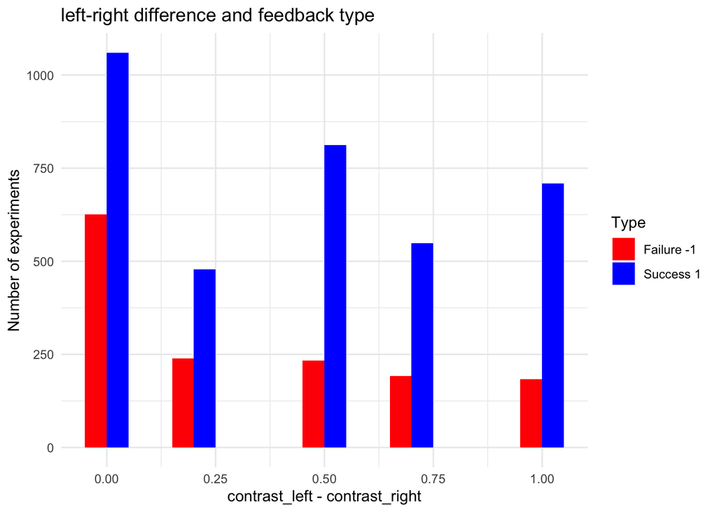

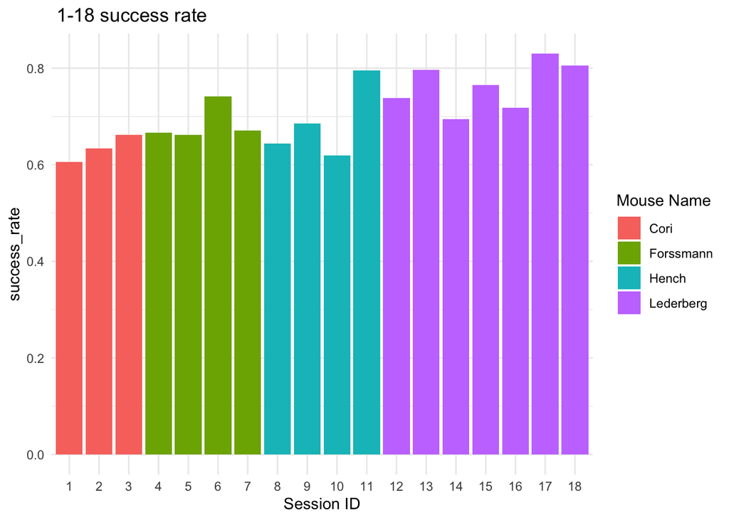

This bar chart shows the relationship between the difference in left and right contrast and the success or failure of the experiment. From the graph, it can be seen that when the contrast on the left and right sides is equal (contrast difference=0.00), the difference between the number of successful experiments and the number of failed experiments is not very large. This indicates that the accuracy of mice is slightly lower when the left and right sides are the same, which may be influenced by experimental control factors or their own decision-making preferences.

### 2.3) The relationship between all stimuli is 0 and the feedback type & all stimuli is equal and the feedback type

```
##   session_id mouse_name zero_trials_count left_choice_count right_choice_count
## 1          1       Cori                24                16                  8
## 2          2       Cori                66                47                 19
## 3          3       Cori                76                47                 29
## 4          4  Forssmann                68                61                  7
## 5          5  Forssmann                71                53                 18
## 6          6  Forssmann                79                62                 17
##   left_choice_rate right_choice_rate
## 1        0.6666667         0.3333333
## 2        0.7121212         0.2878788
## 3        0.6184211         0.3815789
## 4        0.8970588         0.1029412
## 5        0.7464789         0.2535211
## 6        0.7848101         0.2151899
```

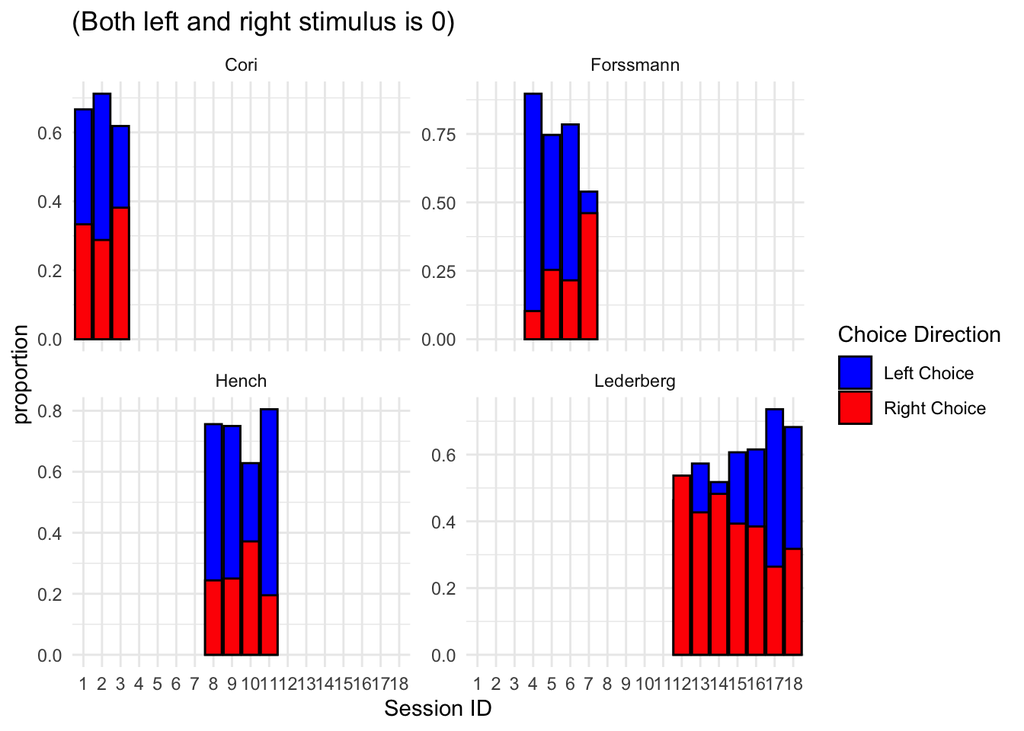

These histograms show the proportional distribution of left and right stimuli selected by mice and grouped according to mice, with both stimuli being 0. Overall, mice show a certain left preference under this symmetrical stimulation condition. If the selection is random, theoretically we should observe that the selection ratio is close to 50%, the height of the blue (left) and red (right) bar charts should be roughly equal.

In actual data, the proportion of left-side selection (blue) is significantly higher than that of right-side selection (red), especially in the experiments of Forsmann and Hench in mice.This preference may stem from differences in behavioral habits, or brain function. This analysis provides assistance for predictive models. If the left selection rate deviates significantly from 50%, it indicates that the feedback type is not completely random, but is influenced by inherent preferences or other factors, which may affect the model’s ability to predict results under these conditions.

```
##   session_id mouse_name total_trials equal_stimulus_count equal_stimulus_rate
## 1          1       Cori          114                   30           0.2631579
## 2          2       Cori          251                   87           0.3466135
## 3          3       Cori          228                   98           0.4298246
## 4          4  Forssmann          249                   85           0.3413655
## 5          5  Forssmann          254                   95           0.3740157
## 6          6  Forssmann          290                  100           0.3448276
```

```
##   session_id mouse_name equal_trials_count left_choice_count right_choice_count
## 1          1       Cori                 30                18                 12
## 2          2       Cori                 87                56                 31
## 3          3       Cori                 98                59                 39
## 4          4  Forssmann                 85                67                 18
## 5          5  Forssmann                 95                67                 28
## 6          6  Forssmann                100                74                 26
##   left_choice_rate right_choice_rate
## 1        0.6000000         0.4000000
## 2        0.6436782         0.3563218
## 3        0.6020408         0.3979592
## 4        0.7882353         0.2117647
## 5        0.7052632         0.2947368
## 6        0.7400000         0.2600000
```

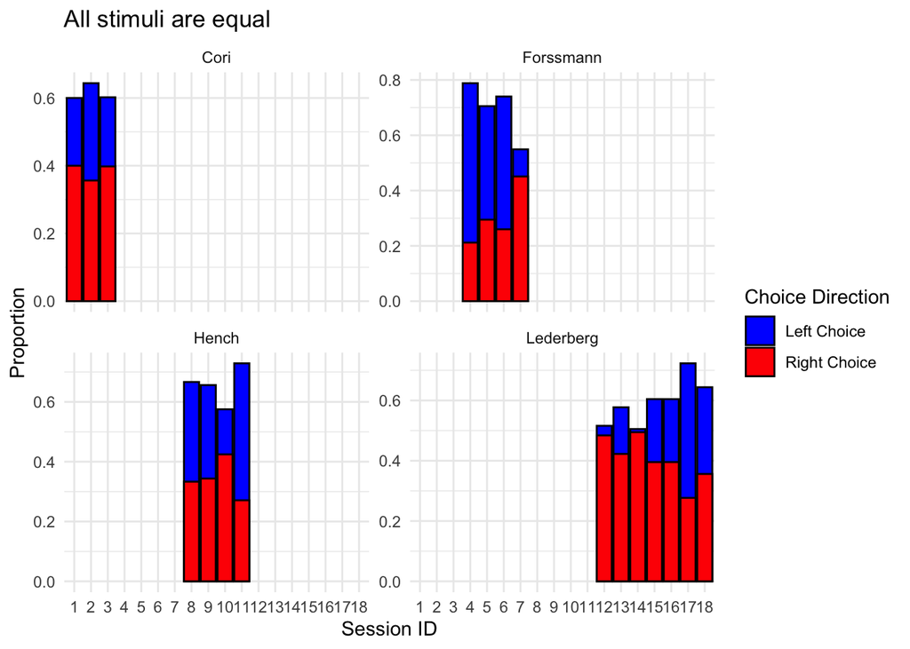

This analysis provides assistance for predictive models by examining whether mice exhibit selection bias (contrast difference=0 or contrast left=contrast right) in the absence or similarity of left and right stimuli. Finally, since the prediction error is usually higher when the contrast diff=0, this analysis helps explain why relying solely on the contrast diff may not be sufficient for accurate prediction. On the contrary, combining neural activity features (SPK) enhances the model’s ability to capture decision patterns, which should improve predictive performance.

### 2.4) numbers of spikes of neurons in the visual cortex in time bins

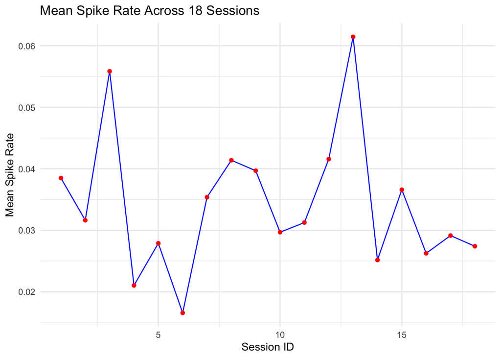

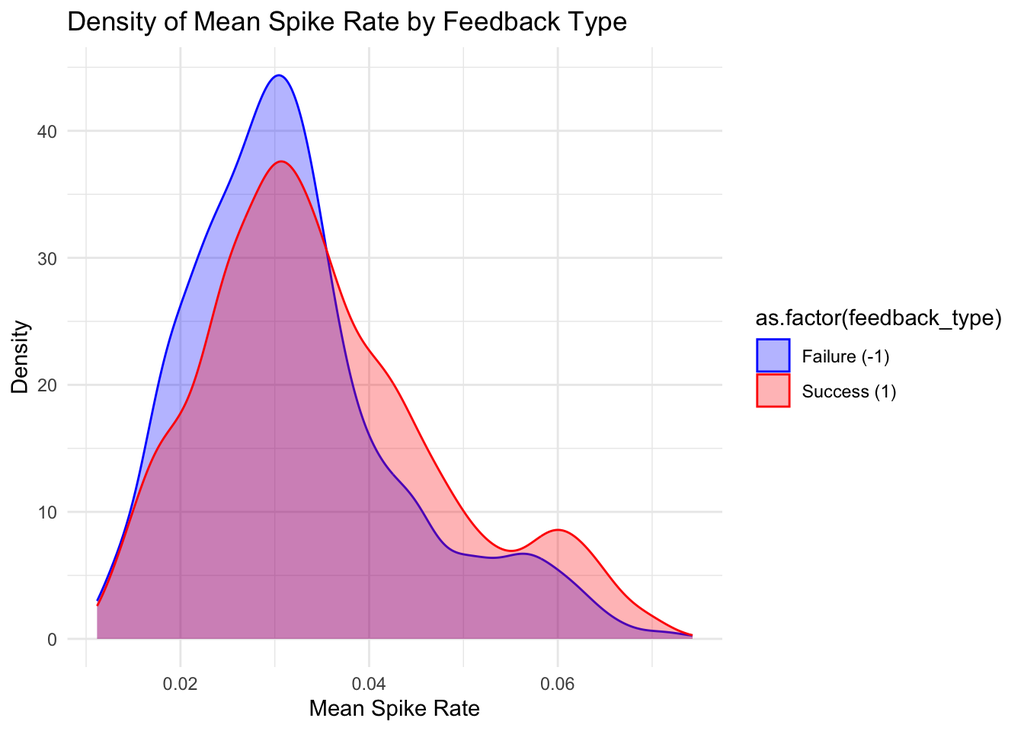

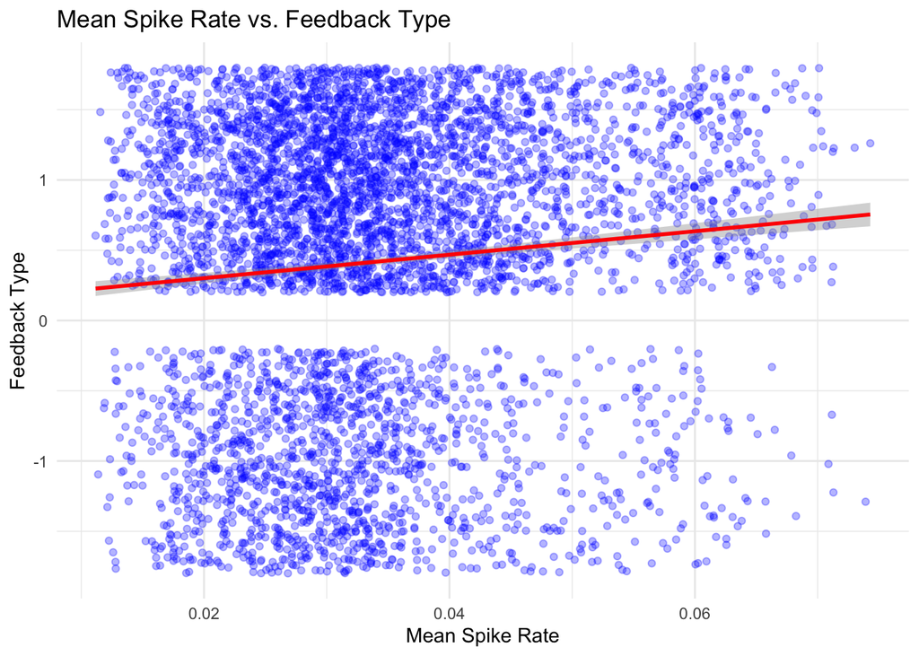

From the density plot, it can be seen that there are certain differences in the Mean Spike Rate under different Feedback Types (success 1 vs failure -1). The Mean Spike Rate distribution of the successful group is generally skewed to the right, meaning that the Mean Spike Rate of successful trials is slightly higher than that of failed trials. In the area above 0.04, the density of the successful group (red curve) is higher than that of the failed group, while between 0.02-0.03, the density of the failed group (blue curve) is higher, indicating that a higher Mean Spike Rate may help improve the success rate. However, there is still significant overlap between the density curves of the two groups, indicating that the influence of Mean Spike Rate on feedback results is not a decisive factor, but rather a combined effect with other variables such as Contrast Difference. Added a scatter plot, where the red regression line slopes upwards to further demonstrate that higher mean spike rates have a higher success rate. From the perspective of model optimization, Mean Spike Rate as an input feature can provide certain predictive information, which can be used in XGBoost training to further analyze its importance and determine its contribution to decision results.

```
##   session_id mouse_name feedback_type early_spike_rate late_spike_rate
## 1          1       Cori             1       0.03188011      0.04720708
## 2          1       Cori             1       0.02963215      0.03596730
## 3          1       Cori            -1       0.04509537      0.04713896
## 4          1       Cori            -1       0.03964578      0.02942779
## 5          1       Cori            -1       0.03671662      0.03453678
## 6          1       Cori             1       0.02445504      0.03024523
```

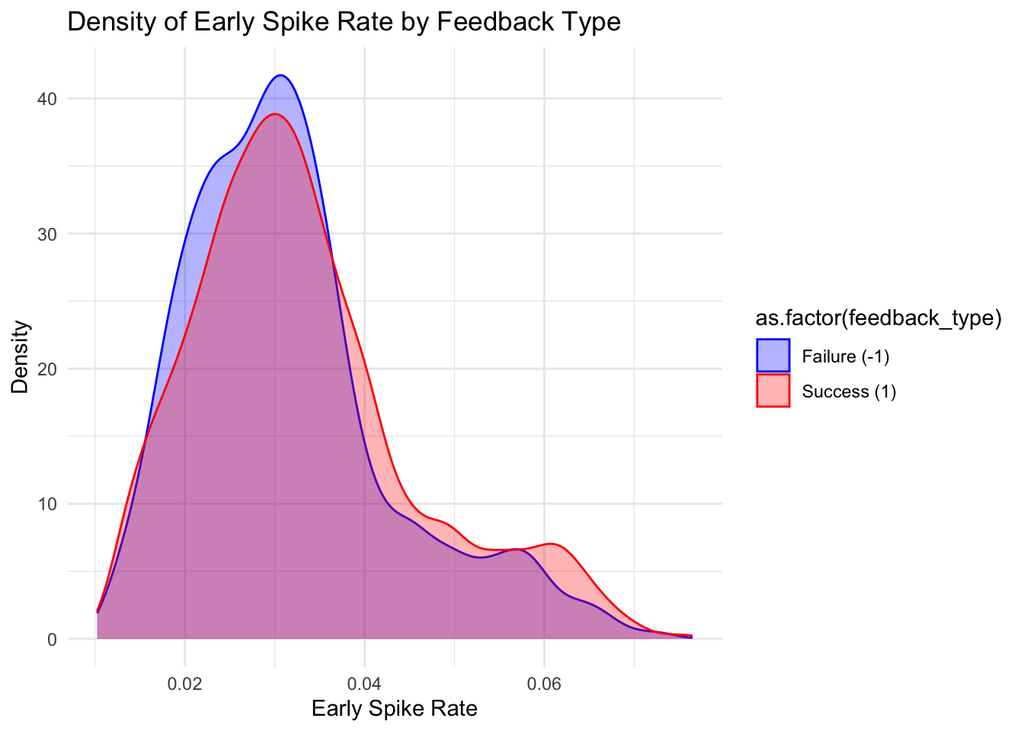

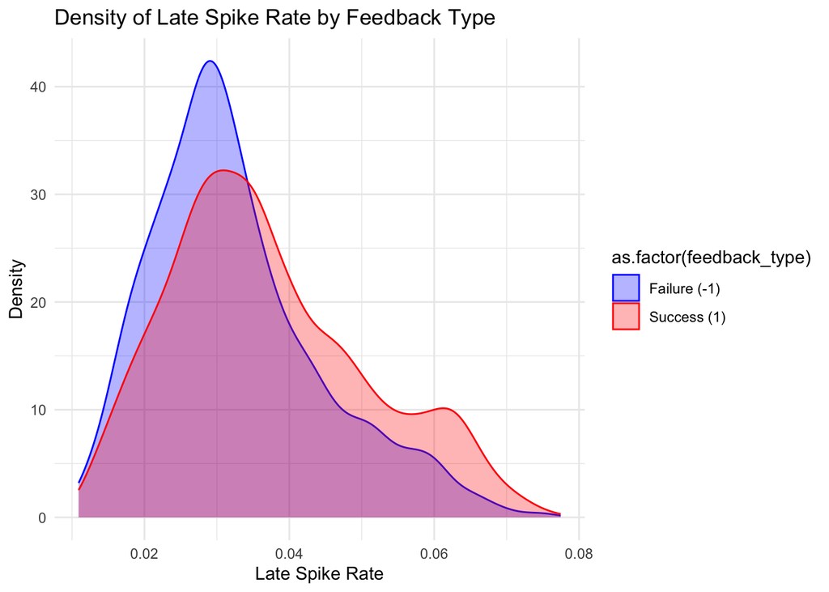

From the graph, it can be seen that the distribution of neural discharge rates for success (red) and failure (blue) is different. For Early Spike Rate, the density of failures is higher at lower values, while the density of successes is slightly higher at higher values, indicating that higher Early Spike Rates may be more likely to succeed, but the difference is not significant. For Late Spike Rate, the success density is more pronounced at higher values, while the failure density is higher at lower values, indicating that higher Late Spike Rate is more likely to lead to success. Overall, Late Spike Rate may have a greater impact on success rate than Early Spike Rate, but both features can be used for model prediction.

### 2.5) neurons

```
##   session_id mouse_name total_neurons brain_areas
## 1          1       Cori           734           8
## 2          2       Cori          1070           5
## 3          3       Cori           619          11
## 4          4  Forssmann          1769          11
## 5          5  Forssmann          1077          10
## 6          6  Forssmann          1169           5
```

```
##   brain_area neuron_count
## 1        ACA          540
## 2        ACB          155
## 3        AUD          246
## 4        BLA          132
## 5        CA1          799
## 6        CA3          360
```

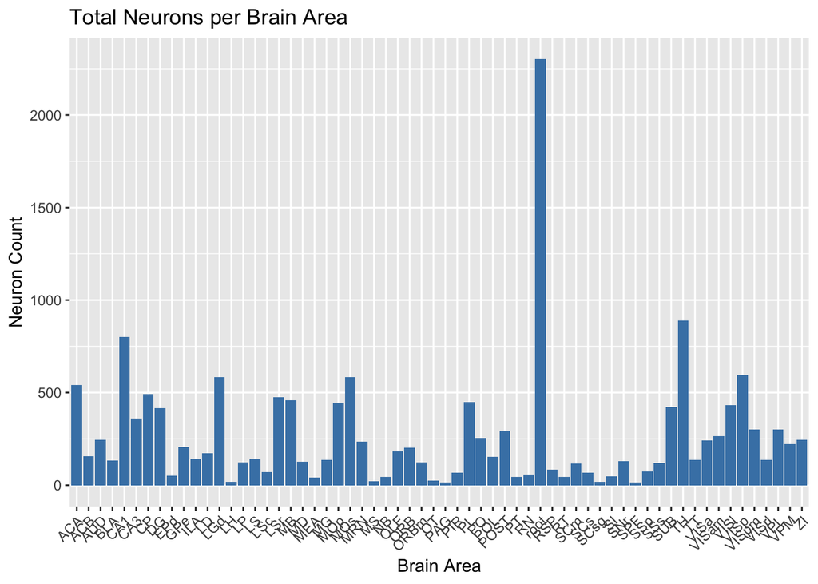

This graph shows the number of neurons recorded in each brain region and displays the distribution of neurons in different regions of the dataset. Overall, there are significant differences in the number of neurons in different brain regions, with more neurons in CA1, CA3, ACA, MOp, MOs, TH, VISp, and other areas mainly involved in memory, action, and vision, which may be related to left and right decision-making in mice. However, the number of neurons in the “root” area is much more than in other areas, which may be a neuron unrelated to the experimental purpose.

# 3 Data integration

### 3.1)integrate data

```
##   session_id mouse_name contrast_diff feedback_type mean_spike_rate
## 1          1       Cori          -0.5             1      0.03954360
## 2          1       Cori           0.0             1      0.03279973
## 3          1       Cori          -0.5            -1      0.04611717
## 4          1       Cori           0.0            -1      0.03453678
## 5          1       Cori           0.0            -1      0.03562670
## 6          1       Cori           0.0             1      0.02735014
##   spike_variability early_spike_rate late_spike_rate peak_spike_time
## 1         0.2087276       0.03188011      0.04720708              NA
## 2         0.1863394       0.02963215      0.03596730              NA
## 3         0.2240335       0.04509537      0.04713896              NA
## 4         0.1943530       0.03964578      0.02942779              NA
## 5         0.2034089       0.03671662      0.03453678              NA
## 6         0.1759626       0.02445504      0.03024523              NA
```

### 3.2) PCA analysis

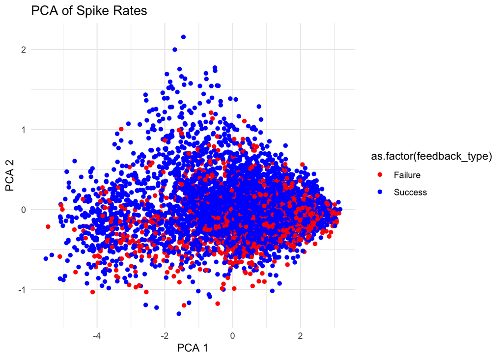

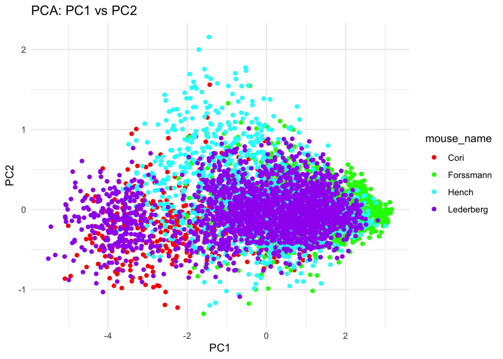

In this section of data integration, I used principal component analysis (PCA) to reduce the dimensionality of neural activity features (such as spike rate) and identified the most important patterns of change in the data. Each principal component (PC) represents an important direction in the raw data. Specifically, the figure shows the results of PCA dimensionality reduction and analyzes the principal components. From the figure, it can be seen that different types of feedback (red indicates failure, blue indicates success) have significant overlap in the distribution of PC1 and PC2.

Although there are certain differences in neural activity between success and failure, these differences may not be very significant, especially in principal component space. But PCA analysis helped us reduce dimensions and provided assistance for the models.

# 4 Predictive modeling

### 4.1) Model selection

```
## [1] "logistic_model Accuracy: 0.7515"
## [1] "rf_model Accuracy: 0.6879"
## [1] "xgb_model Accuracy: 0.6939"
```

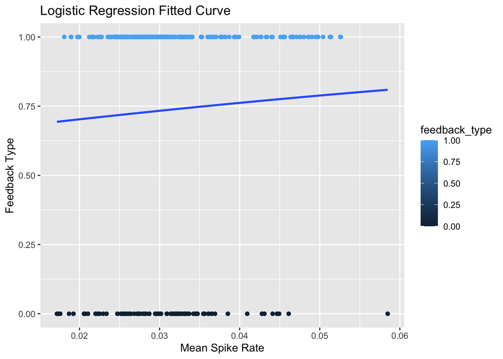

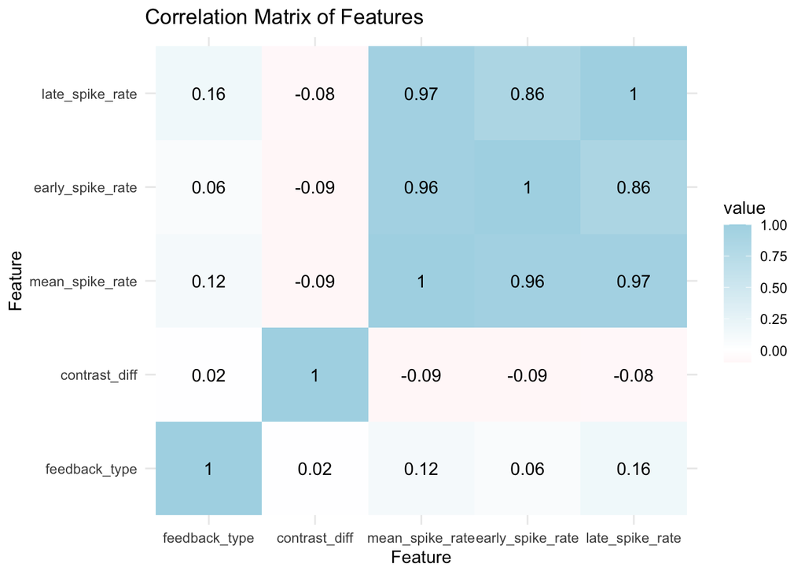

In the model section, I created three different models to predict data: Logistic Regression, Random Forest, and XGBoost. Each model has its unique advantages and is suitable for different types of data. Logistic regression, as a linear model, is used to explore the linear relationship between different features (such as contrast differences, average spike rates, etc.) and feedback types. The accuracy of the model is around 75, indicating that it can predict the feedback types of success and failure to a certain extent.

–Why not choose logistic regression?

However, logistic regression can only handle linear relationships and may have limited performance when dealing with complex data.From the graph, the model can only capture simple linear relationships, but does not take into account possible complex interaction effects or nonlinear features.

From the correlation plot, it can be seen that the correlation between feedback_date and other variables is low, especially with variables such as contrast-diff, mean_spike rate, and early_spike rate, which are very weak. This means that the relationship between feedbacked type and these features is not linear, so the accuracy of using a linear model to predict feedbacked type will be limited.

–Why chose XGBoost model

Random forest, as an ensemble learning method, can handle nonlinear relationships and high-dimensional data, and has stronger generalization ability. Its accuracy is aroud 70, indicating a certain advantage in processing complex data. XGBoost, on the other hand, is a gradient boosting tree method with powerful predictive capabilities, especially suitable for handling complex and high-dimensional data. Although XGBoost’s accuracy is slightly lower than logistic regression, its ability to express large and complex data far surpasses other models, so I chose XGBoost as the final model.

### 4.2) Model training

In the process of training the XGBoost model, I used data from sessions 2 to 17 for training. I extracted features such as contrast-diff, mean_stike_rate, early_stike_rate, late_stike_rate, etc. from train_data, and included mouse_name to distinguish different mice. I will use feedbacked type as the target variable and classify it into 0 and 1. In order to optimize the performance of the model, I set some hyperparameters of XGBoost, such as the maximum depth of the tree (7), learning rate (0.1), etc., and used 50 rounds of boosting. Through these steps, I have finally developed a model for predicting feedback types (success or failure), and I will evaluate its performance using test data.

# 5 Prediction performance on the test sets

### 5.1) Model testing performance from session 1 and 18

```
## [1] "XGBoost Model Accuracy: 0.7515"
```

```
##           Reference
## Prediction   0   1
##          0  11   6
##          1  76 237
```

In this section of model testing, I used data from sessions 1 and 18 to evaluate the performance of the model. Firstly, I have the model make predictions and then convert the predicted results into labels of 0 or 1. Next, I calculated the accuracy of the model, which is the proportion of its correct predictions. Then, I used a confusion matrix to help understand the performance of the model. This matrix displays the relationship between the predicted results and the actual results. For example, how many times has the model predicted “success” but actually “failure”, or how many times has the model predicted “failure” but actually “success”. From the test results, the accuracy of the model is 75.15%.

# 6 Discussion

### 6.1) Model Performance & Confusion Matrix analysis

```
## Confusion Matrix and Statistics
##
##           Reference
## Prediction   0   1
##          0  11   6
##          1  76 237
##
##                Accuracy : 0.7515
##                  95% CI : (0.7012, 0.7972)
##     No Information Rate : 0.7364
##     P-Value [Acc > NIR] : 0.2893
##
##                   Kappa : 0.1372
##
##  Mcnemar's Test P-Value : 2.541e-14
##
##             Sensitivity : 0.12644
##             Specificity : 0.97531
##          Pos Pred Value : 0.64706
##          Neg Pred Value : 0.75719
##              Prevalence : 0.26364
##          Detection Rate : 0.03333
##    Detection Prevalence : 0.05152
##       Balanced Accuracy : 0.55087
##
##        'Positive' Class : 0
##
```

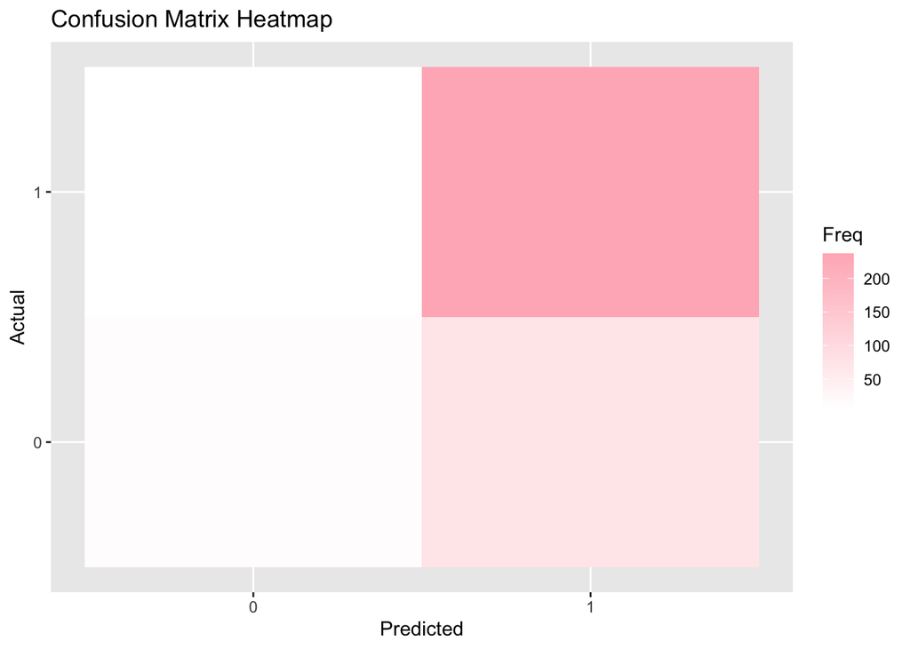

### 6.2) Model Predictors importance analysis

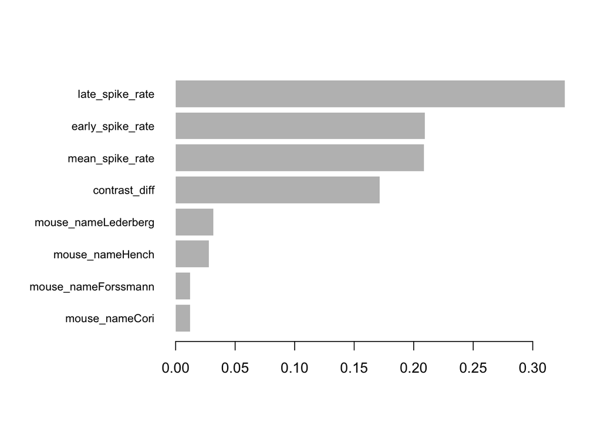